# W_UP_01

Rolando Benitez

Spring 2026

# Introduction

The question is, “is who does more push ups in two minutes- playerson the line or skill position players? data are from Georgetown varsity College football team. data are the number of push ups done in 2 minutes (numerical, continous), position which is a categorical variable.

Create an Rstudio project in your shared space on rstudio.cloud. Using the dataset called pushups from the tigerstats package in R; answer the question posed by this null and alternate hypothesis in an html markdown document.

$H_0$: There is no difference between the average number of pushups of line vs skill players

# Results

## Descriptive Results

### Graphical Descriptive Results

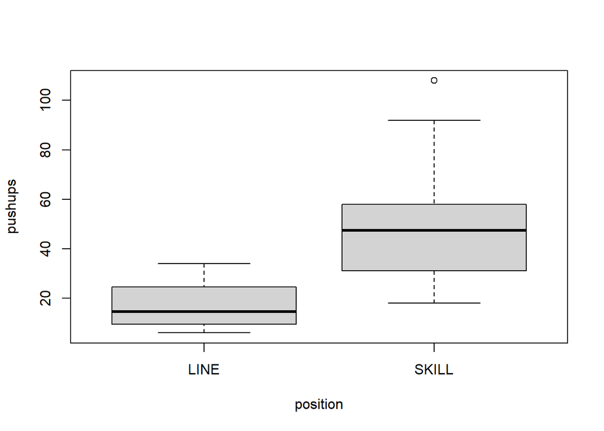

```r
boxplot(pushups~position,data=mydata)
```

### Numerical Descriptive Results

```r
#favstats(pushups~position,data=mydata)
summary(mydata)
```

```
##        X             weight         pushups         position
##  Min.   : 1.00   Min.   :151.0   Min.   :  6.00   Length:30
##  1st Qu.: 8.25   1st Qu.:181.2   1st Qu.: 24.25   Class :character
##  Median :15.50   Median :198.0   Median : 36.00   Mode  :character
##  Mean   :15.50   Mean   :213.7   Mean   : 41.03
##  3rd Qu.:22.75   3rd Qu.:241.0   3rd Qu.: 51.50
##  Max.   :30.00   Max.   :300.0   Max.   :108.00
```

## Inferential Results

```r
t.test(pushups~position,data=mydata)
```

```
##
##  Welch Two Sample t-test
##
## data:  pushups by position
## t = -5.4341, df = 27.079, p-value = 9.421e-06
## alternative hypothesis: true difference in means between group LINE and group SKILL is not equal to 0
## 95 percent confidence interval:
##  -44.91068 -20.29387
## sample estimates:
##  mean in group LINE mean in group SKILL
##            17.12500            49.72727
```

# Discussion and Conclusion

The p value comparing the two groups is .000009 this is smaller than .05 so we reject the null hypothesis and conclude we have the skill position players can do more push ups than the line players.

we reject the null hypothesis because the p value is .000009 and is less than .05